# **Brandon Schmidt Project 1 - FoodHub**

### Context

The number of restaurants in New York is increasing day by day. Lots of students and busy professionals rely on those restaurants due to their hectic lifestyles. Online food delivery service is a great option for them. It provides them with good food from their favorite restaurants. A food aggregator company FoodHub offers access to multiple restaurants through a single smartphone app.

The app allows the restaurants to receive a direct online order from a customer. The app assigns a delivery person from the company to pick up the order after it is confirmed by the restaurant. The delivery person then uses the map to reach the restaurant and waits for the food package. Once the food package is handed over to the delivery person, he/she confirms the pick-up in the app and travels to the customer's location to deliver the food. The delivery person confirms the drop-off in the app after delivering the food package to the customer. The customer can rate the order in the app. The food aggregator earns money by collecting a fixed margin of the delivery order from the restaurants.

### Objective

The food aggregator company has stored the data of the different orders made by the registered customers in their online portal. They want to analyze the data to get a fair idea about the demand of different restaurants which will help them in enhancing their customer experience. Suppose you are hired as a Data Scientist in this company and the Data Science team has shared some of the key questions that need to be answered. Perform the data analysis to find answers to these questions that will help the company to improve the business.

### Data Description

The data contains the different data related to a food order. The detailed data dictionary is given below.

### Data Dictionary

- order_id: Unique ID of the order
- customer_id: ID of the customer who ordered the food
- restaurant_name: Name of the restaurant
- cuisine_type: Cuisine ordered by the customer
- cost_of_the_order: Cost of the order
- day_of_the_week: Indicates whether the order is placed on a weekday or weekend (The weekday is from Monday to Friday and the weekend is Saturday and Sunday)
- rating: Rating given by the customer out of 5
- food_preparation_time: Time (in minutes) taken by the restaurant to prepare the food. This is calculated by taking the difference between the timestamps of the restaurant's order confirmation and the delivery person's pick-up confirmation.
- delivery_time: Time (in minutes) taken by the delivery person to deliver the food package. This is calculated by taking the difference between the timestamps of the delivery person's pick-up confirmation and drop-off information

## File Preparation & Understanding Data Structure

```python
# Mount drive

from google.colab import drive
drive.mount('/content/drive')
```

```python
# Import libraries for data manipulation & developing an ideal data structure

import pandas as pd
import numpy as np

# Import libraries to showcase data visualizations

import matplotlib.pyplot as plt
import seaborn as sns
```

```python
# Import dataset

df = pd.read_csv('/content/drive/MyDrive/AI_ML Post Graduate/Projects/foodhub_order.csv')

# Get quick insight on data column names & show first five rowa of the dataset

df.head()
```

|  | order_id | customer_id | restaurant_name | cuisine_type | cost_of_the_order | day_of_the_week | rating | food_preparation_time | delivery_time |
| --- | --- | --- | --- | --- | --- | --- | --- | --- | --- |
| 0 | 1477147 | 337525 | Hangawi | Korean | 30.75 | Weekend | Not given | 25 | 20 |
| 1 | 1477685 | 358141 | Blue Ribbon Sushi Izakaya | Japanese | 12.08 | Weekend | Not given | 25 | 23 |
| 2 | 1477070 | 66393 | Cafe Habana | Mexican | 12.23 | Weekday | 5 | 23 | 28 |
| 3 | 1477334 | 106968 | Blue Ribbon Fried Chicken | American | 29.20 | Weekend | 3 | 25 | 15 |
| 4 | 1478249 | 76942 | Dirty Bird to Go | American | 11.59 | Weekday | 4 | 25 | 24 |

*Observations*

Column names of the dataset include:

1. 'order_id'
2. 'customer_id'
3. 'restaurant_name'
4. 'cuisine_type'
5. 'cost_of_the_order'
6. 'day_of_the_week'
7. 'rating'
8. 'food_preparation_time'
9. 'delivery_time'

## Basic Info & Statistical Summary

### Question 1: How many rows and columns are present in the data?

```python
# Identify data shape (rows & columns)

df.shape
```

```
(1898, 9)
```

*Observation*

The 'food_order' dataset set has a total of 1898 rows and 9 different columns.

### Question 2: What are the datatypes of the different columns in the dataset?

```python
# Obtain insight on data types within the dataset

df.info()
```

```
<class 'pandas.core.frame.DataFrame'>
RangeIndex: 1898 entries, 0 to 1897
Data columns (total 9 columns):
 #   Column                 Non-Null Count  Dtype
---  ------                 --------------  -----
 0   order_id               1898 non-null   int64
 1   customer_id            1898 non-null   int64
 2   restaurant_name        1898 non-null   object
 3   cuisine_type           1898 non-null   object
 4   cost_of_the_order      1898 non-null   float64
 5   day_of_the_week        1898 non-null   object
 6   rating                 1898 non-null   object
 7   food_preparation_time  1898 non-null   int64
 8   delivery_time          1898 non-null   int64
dtypes: float64(1), int64(4), object(4)
memory usage: 133.6+ KB
```

*Observation*

The food_order dataset has the following data types:

1. Four integers
2. Four objects
3. One float

### Question 3: Are there any missing values in the data?

```python
# Identify missing values & show details

df.isnull().sum()
```

```
order_id                 0
customer_id              0
restaurant_name          0
cuisine_type             0
cost_of_the_order        0
day_of_the_week          0
rating                   0
food_preparation_time    0
delivery_time            0
dtype: int64
```

*Observation*

The food_order dataset has no missing values.

### Question 4: Check the statistical summary of the data. What is the minimum, average, and maximum time it takes for food to be prepared once an order is placed?

```python
# Review & understand datasets statical summary

df.describe().T
```

|  | count | mean | std | min | 25% | 50% | 75% | max |
| --- | --- | --- | --- | --- | --- | --- | --- | --- |
| order_id | 1898.0 | 1.477496e+06 | 548.049724 | 1476547.00 | 1477021.25 | 1477495.50 | 1.477970e+06 | 1478444.00 |
| customer_id | 1898.0 | 1.711685e+05 | 113698.139743 | 1311.00 | 77787.75 | 128600.00 | 2.705250e+05 | 405334.00 |
| cost_of_the_order | 1898.0 | 1.649885e+01 | 7.483812 | 4.47 | 12.08 | 14.14 | 2.229750e+01 | 35.41 |
| food_preparation_time | 1898.0 | 2.737197e+01 | 4.632481 | 20.00 | 23.00 | 27.00 | 3.100000e+01 | 35.00 |
| delivery_time | 1898.0 | 2.416175e+01 | 4.972637 | 15.00 | 20.00 | 25.00 | 2.800000e+01 | 33.00 |

```python
# Obtain min, max, and avg food prepartion time

df['food_preparation_time'].describe()
```

```
count    1898.000000
mean       27.371970
std         4.632481
min        20.000000
25%        23.000000
50%        27.000000
75%        31.000000
max        35.000000
Name: food_preparation_time, dtype: float64
```

*Observation*

The average food preparation time is 27.37 minutes, with a minium prepartation time of 20 minutes and maximum of 35 minutes.

### Question 5: How many orders are not rated?

```python
# Show unique order rating values

df['rating'].unique()
```

```
array(['Not given', '5', '3', '4'], dtype=object)
```

```python
# Identify how many orders are not rated

df['rating'].value_counts()
```

```
rating
Not given    736
5            588
4            386
3            188
Name: count, dtype: int64
```

*Observation*

The food_order dataset has 736 orders that did not receive a rating.

## Exploratory Data Analysis (EDA)

Univariate Analysis

### Question 6: Explore all the variables and provide observations on their distributions.

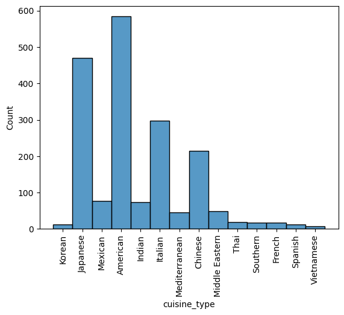

```python
# Identify data distibution of cuisine types & analyze what cuisine type are mostly ordered

plt.xticks(rotation=90)
sns.histplot(data=df, x='cuisine_type')
```

*Observation*

Top three of cuisine types ordered:

1. Amercian
2. Japanese
3. Italian

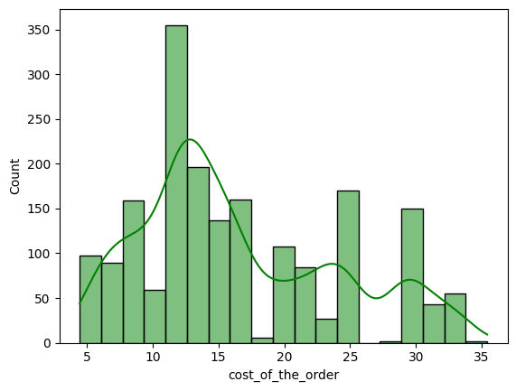

```python
# Identify data skewness and distribution

sns.histplot(data=df, x='cost_of_the_order', kde=True, color='green')
```

```python
# Determine average order cost

df['cost_of_the_order'].value_counts().mean().round(2)
```

```
6.08
```

*Observation*

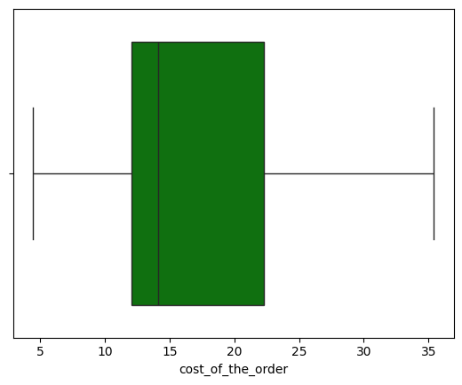

```python
# Identify data distribution of order costs and quartile ranges

sns.boxplot(data=df, x='cost_of_the_order', color='green')
```

*Observation*

Order costs appear to be right-skewed with an Interquartile Range (IQR) between ~12.5-22.5 USD. This means that 50% of all orders cost between ~12.5-22.5 USD. In addition, 75% of all orders cost less than 22.5 USD.

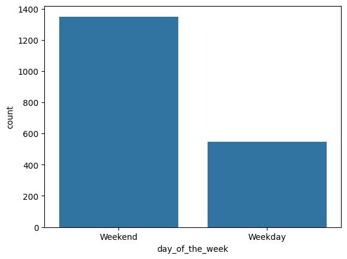

```python
# Analyze count of order by weekend & weekday

sns.countplot(data=df, x='day_of_the_week')
```

```python
# calculate orders by weekend and weekday

df['day_of_the_week'].value_counts()
```

```
day_of_the_week
Weekend    1351
Weekday     547
Name: count, dtype: int64
```

*Observation*

The data shows that most orders are made during weekends. 1351 orders were placed on weekends compared to 547 orders on weekedays.

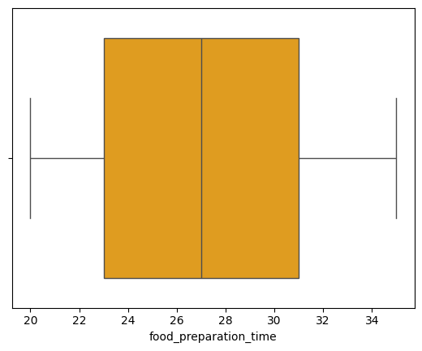

```python
# Identify data distibution of food preparation times and quartile ranges

sns.boxplot(data=df, x='food_preparation_time', color='orange')
```

*Observation*

The food preparation datapoint appears to be evenly distrubted with an Interquartile Range (IQR) between 23-31 minutes. This mean that 50% of all orders were prepared within that timeframe.

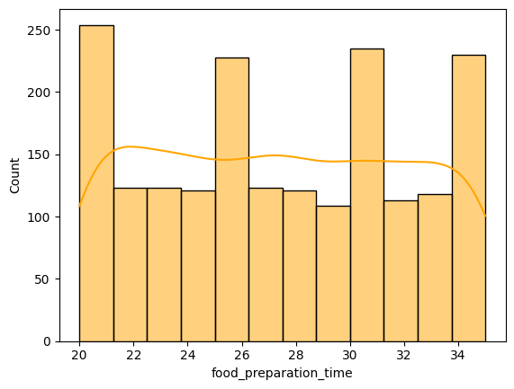

```python
# Identify data skewness for food preparation times

sns.histplot(data=df, x='food_preparation_time', kde=True, color='orange')
```

*Observation*

No skewness detected.

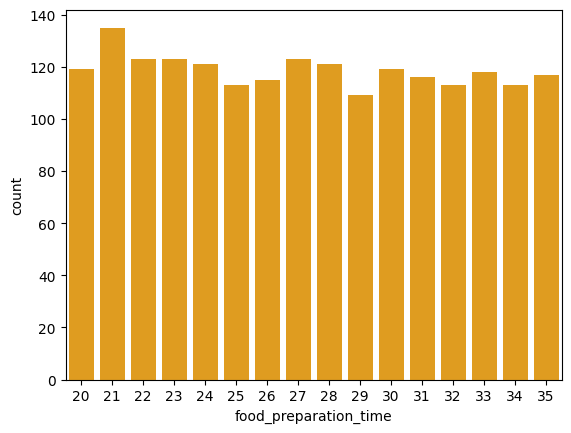

```python
# Analyze food preparation time in further detail

sns.countplot(data=df, x='food_preparation_time', color='orange')
```

*Observation*

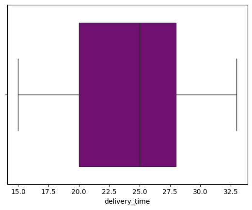

```python
# Identify data distribution of delivery times

sns.boxplot(data=df, x='delivery_time', color='purple')
```

*Observation*

The data shows that 75% of all orders are delivered ~below 28 minutes. The IQR (50% of all orders) are between 20-28 minutes. No significant skewness detected.

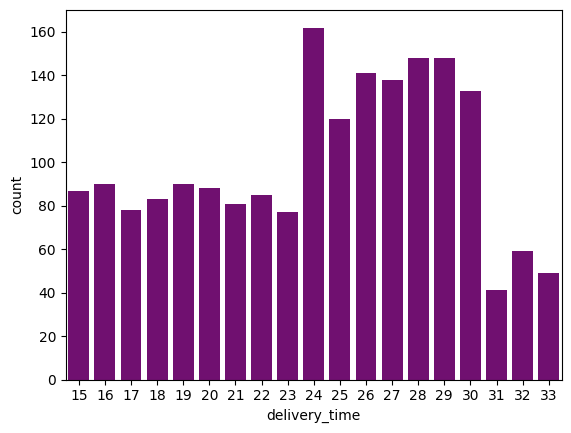

```python
# Identify most frequent delivery times

sns.countplot(data=df, x='delivery_time', color='purple')
```

*Observation*

The most frequent delivery time is 24 minutes according to the dataset.

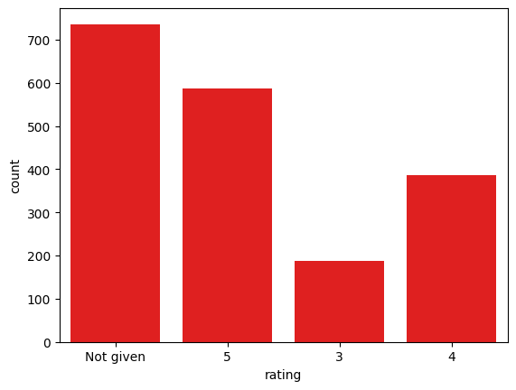

```python
# Analyze count of orders by rating

sns.countplot(data=df, x='rating', color='red')
```

*Observation*

Most occured rating is 'not given' followed by '5', '4', and lastly '3'.

### Question 7: Which are the top 5 restaurants in terms of the number of orders received?

```python
# Gather top five restaurants by by orders received

df['restaurant_name'].value_counts().head(5)
```

```
restaurant_name
Shake Shack                  219
The Meatball Shop            132
Blue Ribbon Sushi            119
Blue Ribbon Fried Chicken     96
Parm                          68
Name: count, dtype: int64
```

*Observation*

The top five restaurants are as follows:

1. Shake Shack
2. The Meatball Shop
3. Blue Ribbon Sushi
4. Blue Ribbon Fried Chicken
5. Parm

### Question 8: Which is the most popular cuisine on weekends?

```python
# Analyze cuisine popularity on weekends and identify most popular

df[df['day_of_the_week'] == 'Weekend']['cuisine_type'].value_counts().head(1)
```

```
cuisine_type
American    415
Name: count, dtype: int64
```

*Observation*

The most popular cuisine on the weekends is Amercian with a total of 415 orders.

### Question 9: What percentage of the orders cost more than 20 dollars?

```python
# Percentage orders above 20 USD

(df[df['cost_of_the_order']>20]['cost_of_the_order'].count() / df['cost_of_the_order'].count() * 100).round(2)
```

```
29.24
```

*Observation*

Analysis of the dataset shows that 29.24% of all orders cost more than 20 USD.

### Question 10: What is the mean order delivery time?

```python
# What is the avg. delivery time

df['delivery_time'].mean().round(2)
```

```
24.16
```

```python
# Determine partial minute of 0.16 in seconds

int(60 * 0.16)
```

```
9
```

*Observation*

The average/mean order delivery time is 24.16 minutes or 24 minutes & ~9 seconds.

### Question 11: The company has decided to give 20% discount vouchers to the top 3 most frequent customers. Find the IDs of these customers and the number of orders they placed.

```python
# Determine top three customers by amount of time they ordered

df['customer_id'].value_counts().head(3)
```

```
customer_id
52832    13
47440    10
83287     9
Name: count, dtype: int64
```

*Observation*

Top three rankings of customers by orders:

1. Customer 52832 is number one with a total of 13 orders.
2. Customer 47440 is number two with a total of 10 orders.
3. Customer 83287 is number three with a total of 9 orders.

Therefore, customer 52832, 47440, and 83287 receive 20% discount vouchers from FoodHub.

## Exploratory Data Analysis (EDA)

Multivariate Analysis

### Question 12: Perform a multivariate analysis to explore relationships between the important variables in the dataset.

```python
# Gain data types to conduct relationship analysis

df.info()
```

```
<class 'pandas.core.frame.DataFrame'>
RangeIndex: 1898 entries, 0 to 1897
Data columns (total 9 columns):
 #   Column                 Non-Null Count  Dtype
---  ------                 --------------  -----
 0   order_id               1898 non-null   int64
 1   customer_id            1898 non-null   int64
 2   restaurant_name        1898 non-null   object
 3   cuisine_type           1898 non-null   object
 4   cost_of_the_order      1898 non-null   float64
 5   day_of_the_week        1898 non-null   object
 6   rating                 1898 non-null   object
 7   food_preparation_time  1898 non-null   int64
 8   delivery_time          1898 non-null   int64
dtypes: float64(1), int64(4), object(4)
memory usage: 133.6+ KB
```

```python
# Build numeric value relationship

corr = df.corr(numeric_only=True)
corr
```

|  | order_id | customer_id | cost_of_the_order | food_preparation_time | delivery_time |
| --- | --- | --- | --- | --- | --- |
| order_id | 1.000000 | -0.013960 | 0.021171 | -0.007026 | 0.009690 |
| customer_id | -0.013960 | 1.000000 | -0.001322 | -0.030330 | -0.009885 |
| cost_of_the_order | 0.021171 | -0.001322 | 1.000000 | 0.041527 | -0.029949 |
| food_preparation_time | -0.007026 | -0.030330 | 0.041527 | 1.000000 | 0.011094 |
| delivery_time | 0.009690 | -0.009885 | -0.029949 | 0.011094 | 1.000000 |

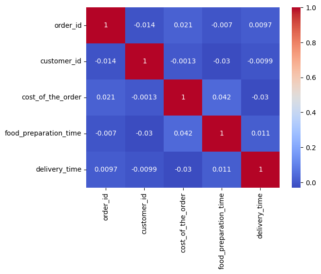

```python
# Analyze correlation using heatmap

sns.heatmap(corr, annot=True, cmap='coolwarm')
```

*Observation*

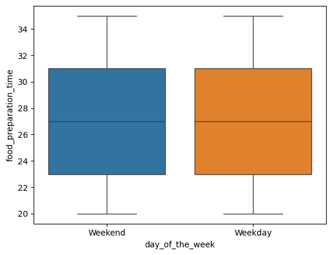

```python
# Data distro of delivery time by weekday/weekend

sns.boxplot(data=df, x='day_of_the_week', y='food_preparation_time', hue='day_of_the_week')
```

*Observation*

Food prepartion times appear to be equally distributed betwen weekends and weekdays. No data skewness detected.

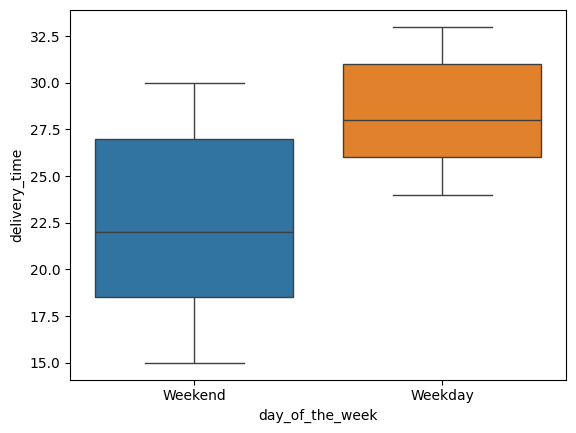

```python
# Data distro of delivery time by weekday/weekend

sns.boxplot(data=df, x='day_of_the_week', y='delivery_time', hue='day_of_the_week')
```

*Observation*

It appears that delivery times are longer for the majority of the time during the weekday compared to the weekend.

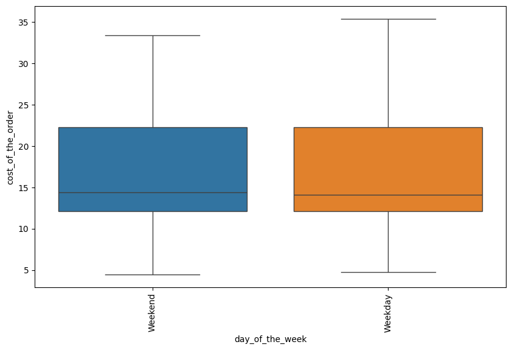

```python
# Data distro of orders by weekday/weekend

plt.figure(figsize=(10, 6))
plt.xticks(rotation=90)
sns.boxplot(data=df, x='day_of_the_week', y='cost_of_the_order', hue='day_of_the_week')
```

*Observation*

There appears to be no significant difference in order costs when costs to weekends/weekdays.

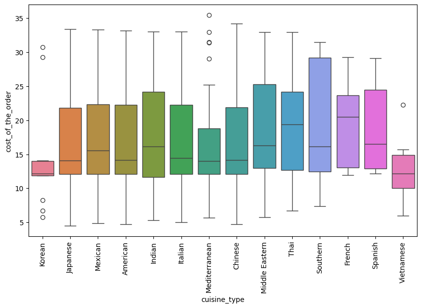

```python
# Identify data distribution between cost of orders based on cuisine type

plt.figure(figsize=(10, 6))
plt.xticks(rotation=90)
sns.boxplot(data=df, x='cuisine_type', y='cost_of_the_order', hue='cuisine_type')
```

*Observations*

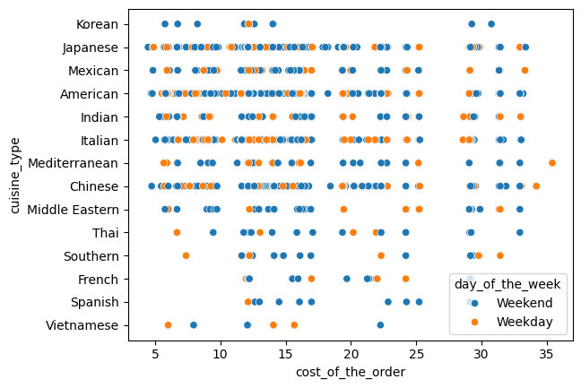

```python
# Identify correlation of order cost by weekend / weekday

sns.scatterplot(data=df, x='cost_of_the_order', y='cuisine_type', hue='day_of_the_week')
```

*Observations*

It appears that order costs do not significanlty vary between weekday or weekends.

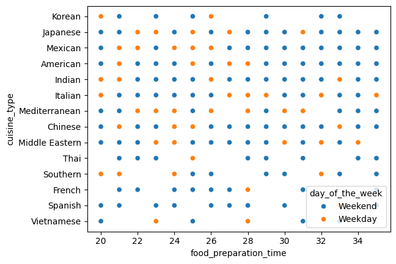

```python
# Identify correlation of preparation time by weekend / weekday

sns.scatterplot(data=df, x='food_preparation_time', y='cuisine_type', hue='day_of_the_week')
```

*Observations*

It appears that Korean, Japanese, Mexican, American, Indian, and Chinese cuisines have a longer food preparation time on weekends compared to weekdays.

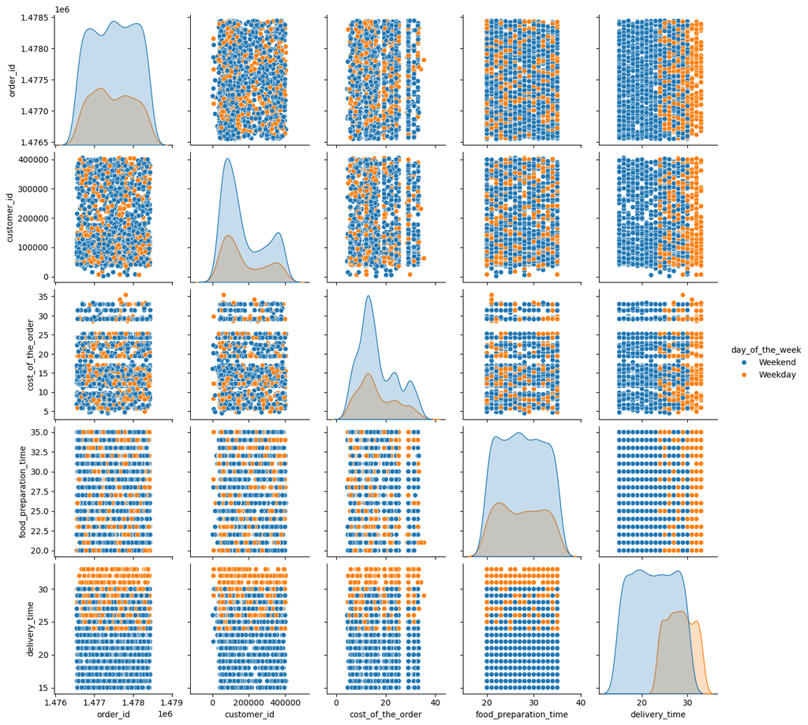

```python
# Showcase variable relationships in regard to weekends/days

plt.figure(figsize=(20,10))
sns.pairplot(data=df, hue='day_of_the_week')
```

*Observation*

The pairplot shows variables relationships with one another in regards to weekends/days.

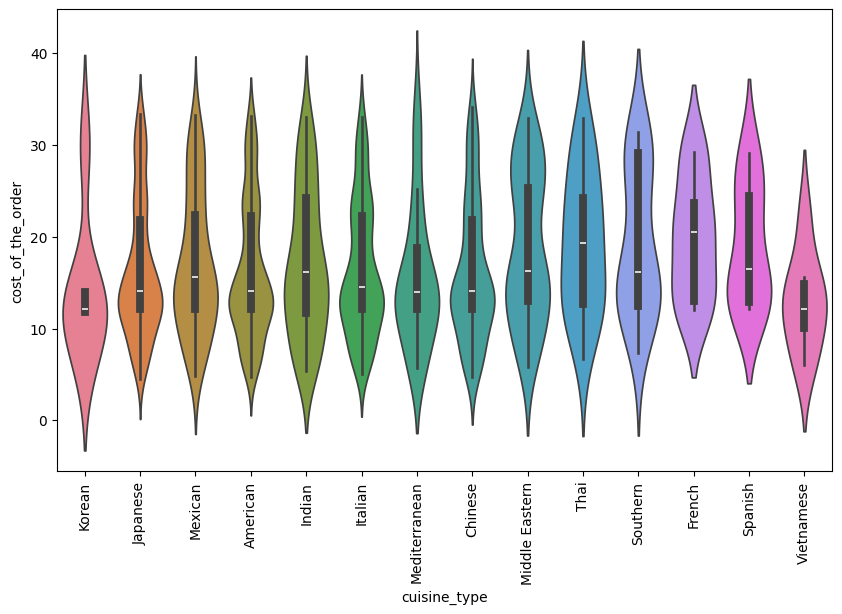

```python
# Analyze relation of food prep time and cost of order

plt.figure(figsize=(10, 6))
plt.xticks(rotation=90)
sns.violinplot(data=df, x='cuisine_type', y='cost_of_the_order', hue='cuisine_type')
```

*Observation*

These violin plots showcase the cost of order by cuisine type distribution on the gray fields which is a box plot representation of the dataset. The white dot in the middle highlights the datas median. The graph thickness/width of each violin diagram shows the probability of that the data.

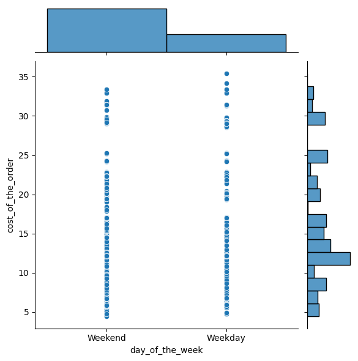

```python
# View cost of order based on weekday/end on a joint plot

sns.jointplot(data=df, x='day_of_the_week', y='cost_of_the_order')
```

*Observation*

Most orders cost between 0 to 25 USD. More orders are place throughout the weekend compared to weekdays.

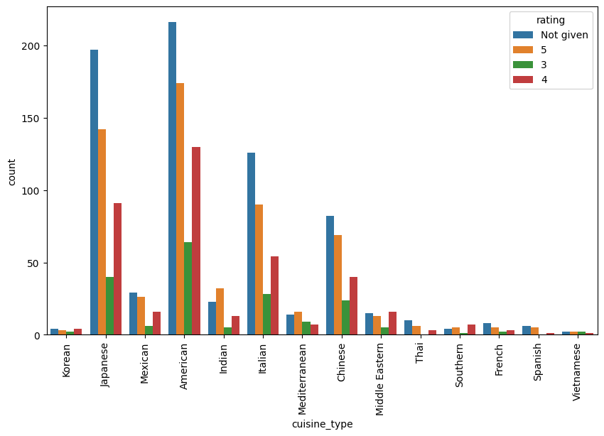

```python
# Identify ratings based on cuisine types

plt.figure(figsize=(10, 6))
plt.xticks(rotation=90)
sns.countplot(data=df, x='cuisine_type', hue='rating')
```

*Observation*

### Question 13: The company wants to provide a promotional offer in the advertisement of the restaurants. The condition to get the offer is that the restaurants must have a rating count of more than 50 and the average rating should be greater than 4. Find the restaurants fulfilling the criteria to get the promotional offer.

```python
# Locate only rated restaurants in dataset

rest_with_ratings = df.drop(df.index[(df['rating'] != '3') & (df['rating'] != '4') & (df['rating'] != '5')])

# Find restaurants with more than 50 ratings
above_50ratings = rest_with_ratings['restaurant_name'].value_counts() > 50
above_50ratings.head(10)
```

```
restaurant_name
Shake Shack                   True
The Meatball Shop             True
Blue Ribbon Sushi             True
Blue Ribbon Fried Chicken     True
RedFarm Broadway             False
Parm                         False
RedFarm Hudson               False
TAO                          False
Rubirosa                     False
Nobu Next Door               False
Name: count, dtype: bool
```

```python
# Find restaurant with more than 50 ratings and a mean of greater than 4

promo_rest = rest_with_ratings.drop(rest_with_ratings.index[(rest_with_ratings['restaurant_name'] != 'Shake Shack')
                   &(rest_with_ratings['restaurant_name'] != 'The Meatball Shop')
                   &(rest_with_ratings['restaurant_name'] != 'Blue Ribbon Sushi')
                   &(rest_with_ratings['restaurant_name'] != 'Blue Ribbon Fried Chicken')])
promo_rest
```

|  | order_id | customer_id | restaurant_name | cuisine_type | cost_of_the_order | day_of_the_week | rating | food_preparation_time | delivery_time |
| --- | --- | --- | --- | --- | --- | --- | --- | --- | --- |
| 3 | 1477334 | 106968 | Blue Ribbon Fried Chicken | American | 29.20 | Weekend | 3 | 25 | 15 |
| 12 | 1476966 | 129969 | Blue Ribbon Fried Chicken | American | 24.30 | Weekend | 5 | 23 | 17 |
| 15 | 1477414 | 66222 | Shake Shack | American | 16.20 | Weekend | 5 | 33 | 25 |
| 19 | 1477354 | 67487 | Blue Ribbon Sushi | Japanese | 16.20 | Weekend | 4 | 35 | 26 |
| 22 | 1478287 | 150599 | Shake Shack | American | 29.10 | Weekday | 5 | 21 | 30 |
| ... | ... | ... | ... | ... | ... | ... | ... | ... | ... |
| 1880 | 1477466 | 222734 | Shake Shack | American | 13.97 | Weekend | 5 | 35 | 27 |
| 1884 | 1477437 | 304993 | Shake Shack | American | 31.43 | Weekend | 3 | 31 | 24 |
| 1885 | 1477550 | 97324 | Shake Shack | American | 29.05 | Weekday | 4 | 27 | 29 |
| 1886 | 1478277 | 48282 | The Meatball Shop | American | 14.50 | Weekend | 5 | 34 | 25 |
| 1888 | 1477353 | 106324 | The Meatball Shop | Italian | 16.20 | Weekend | 5 | 21 | 26 |

354 rows × 9 columns

```python
# Change type to Integer

for column in ['rating']:
    promo_rest[column] = promo_rest[column].astype('int')

# Find averages of restaurants with more and 50 ratings and sort avg. ratings from highest to lowest

promo_rest.groupby('restaurant_name')['rating'].mean().sort_values(ascending = False).head()
```

```
restaurant_name
The Meatball Shop            4.511905
Blue Ribbon Fried Chicken    4.328125
Shake Shack                  4.278195
Blue Ribbon Sushi            4.219178
Name: rating, dtype: float64
```

*Observation*

The following restaurants have over 50 ratings averaging a greater than 4 rating score:

1. The Meatball Shop
2. Blue Ribbon Fried Chicken
3. Shake Shack
4. Blue Ribbon Sushi

These restaurants should all receive the promotional offer!

### Question 14: The company charges the restaurant 25% on the orders having cost greater than 20 dollars and 15% on the orders having cost greater than 5 dollars. Find the net revenue generated by the company across all orders.

```python
# Find the company's net revenue

revenue = df['cost_of_the_order']          # Build dataframe for cost of orders
total_rev = 0                              # Identify total revenue based on criteria

for i in range (len(revenue)):             # Loop through dataframe to calculate total revnue if criteria is met
  if (revenue[i]>5) & (revenue[i]<20):
    total_rev += revenue[i]*0.15
  elif (revenue[i]>20):
    total_rev += revenue[i]*0.25
  else:
    total_rev += 0

print(round(total_rev, 2))
```

```
6166.3
```

*Observation*

The net company revenue of FoodHub is 6,166.30 USD.

### Question 15: The company wants to analyze the total time required to deliver the food. What percentage of orders take more than 60 minutes to get delivered from the time the order is placed? (The food has to be prepared and then delivered.)

```python
# How many orders have a combined food prep and delivery time above 60 min

order_above60min = df[(df['food_preparation_time'] + df['delivery_time']) > 60].count()
order_above60min
```

```
order_id                 200
customer_id              200
restaurant_name          200
cuisine_type             200
cost_of_the_order        200
day_of_the_week          200
rating                   200
food_preparation_time    200
delivery_time            200
dtype: int64
```

```python
# Percentage of order that have a combined delivery and food prep time above 60min compared to all orders

percentage_order_above60min = (order_above60min['order_id'] / df['order_id'].count() * 100).round(2)
percentage_order_above60min
```

```
10.54
```

*Oberservation*

10.54% of all placed orders have a more than 60min delivery time from the time the order is placed. This includes the food preparation time.

### Question 16: The company wants to analyze the delivery time of the orders on weekdays and weekends. How does the mean delivery time vary during weekdays and weekends?

```python
# Calculate and compare mean delivery time of weekends to weekdays

weekday_mean_dtime = df.groupby('day_of_the_week')['delivery_time'].mean()
weekday_mean_dtime
```

```
day_of_the_week
Weekday    28.340037
Weekend    22.470022
Name: delivery_time, dtype: float64
```

```python
# Difference between mean weekday and weekend delivery times

mean_diff = weekday_mean_dtime['Weekday'] - weekday_mean_dtime['Weekend']
mean_diff
```

```
5.870014357297798
```

*Observation*

The mean delivery time is higher on weekdays compared to weekends by approximately 6 minutes.

## Conclusion & Recommendation

### Question 17: What are your conclusions from the analysis? What recommendations would you like to share to help improve the business? (You can use cuisine type and feedback ratings to drive your business recommendations.)

#### Recommendations

1. Encourage users and customers to leave order ratings to improve quality ratings and solicit credible feedback where restaurants can improve. In addition, accurate rating metrics can foster/generate more business for restaurants, but also increase the FoodHub app usage. Recommend giving incentives such as coupons, or other discounts for the next order if consumers leave a rating and review.
2. Develop a strong marketing campaing that encourages customers to use the FoodHub application more frequently during primary workdays/weekdays. Currently, approximately 71 percent of all orders are placed on weekends. This is a great opportunity for FoodHub to increase marketing tactics for weekdays in support of market growth / revenue increase.
3. Recommend analyzing peak traffic times within New York cities to better predicts potential delivery times and allow delvivery personnel to better plan delvery routes.
4. To increase revenue, I would recommend reevaluting charges to restaurants based on the cost of orders IQR being between 12.50 and 22.5 USD. Maybe introduce a flatrate charge of 20%-25% for all orders instead of categorizing charges in three TIERs (0-5 USD, 5-20 USD, 20 USD > )